# Time Series: A First Course with Bootstrap Starter

# Lesson 2-4: Autocovariance

- Now we study the autocovariance function.

## Strict and Weak Stationarity

- Strict stationarity: all marginals (of all orders) are time shift invariant.
- Weak stationarity: the time series has finite variance, constant mean $\mu$, and covariance only depends on lag $h$:
  $$\gamma (h) = \mbox{Cov} [X_t, X_{t-h}] = {\mathbf E} [ X_t \, X_{t-h}] -
  \mu^2.$$
  This function is called the **autocovariance**.
- So the variance is $\gamma (0)$.
- The **autocorrelation** is
  $$\rho (h) = \frac{ \gamma (h) }{ \gamma (0)}.$$
- Weak stationarity is sometimes called *covariance stationarity*.

## Example: Autocorrelation of an AR(1)

- We plot $\rho (h)$ versus $h$ (on x-axis).

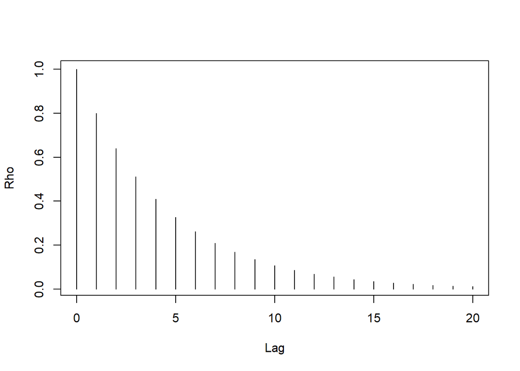

```r
phi <- .8
rho <- phi^seq(0,20)
plot(ts(rho,start=0),xlab="Lag",ylab="Rho",type ="h")
```

## White Noise

- A key example is a *white noise* stochastic process.
- This is any weakly stationary process $\{ Z_t \}$ with mean zero such that $\gamma (h) = 0$ for $h \neq 0$.
- Written compactly as $Z_t \sim \mbox{WN} (0, \sigma^2)$, where $\sigma^2 = \gamma (0)$ is the variance, and the mean is $\mu = 0$.

## Covariance Matrix of Sample Vector

- The time series variables corresponding to a sample are $X_1, \ldots, X_n$, which can be put into a random vector $\underline{X}$.
- The covariance matrix of $\underline{X}$ is denoted by $\Gamma_n$ when the stochastic process is weakly (or strictly) stationary. The entry in row $j$ and column $k$ is
  $$\Gamma_n (j,k) = \mbox{Cov} [ X_j, X_k] = \gamma (k-j).$$
  This only depends on the difference between row and column index! Such a matrix is constant along diagonals, and is called *Toeplitz*.

```r
rho <- .8
gamma <- rho^seq(0,5)/(1-rho^2)
gamma_mat <- toeplitz(gamma)
gamma_mat
```

```
##           [,1]     [,2]     [,3]     [,4]     [,5]      [,6]
## [1,] 2.7777778 2.222222 1.777778 1.422222 1.137778 0.9102222
## [2,] 2.2222222 2.777778 2.222222 1.777778 1.422222 1.1377778
## [3,] 1.7777778 2.222222 2.777778 2.222222 1.777778 1.4222222
## [4,] 1.4222222 1.777778 2.222222 2.777778 2.222222 1.7777778
## [5,] 1.1377778 1.422222 1.777778 2.222222 2.777778 2.2222222
## [6,] 0.9102222 1.137778 1.422222 1.777778 2.222222 2.7777778
```

## Properties of Autocovariance

1. $\gamma (0) \geq 0$
2. $\gamma (h) = \gamma (-h)$
3. $|\gamma (h)| \leq \gamma (0)$.
4. $\gamma (h)$ is a non-negative definite sequence.

This last property means that $\Gamma_n$ is a non-negative definite matrix for all $n$. (Recall from multivariate analysis: covariance matrices are non-negative definite, and are positive definite if all eigenvalues are positive.)